# RPROGRAMMING(EDA)

CHEROTICH FAITH

2022-05-27

###INTRODUCTION

##DEFINING THE RESEARCH QUESTION

Identify individuals who are more likely to click on the Ads posted on her blog

##METRIC OF SUCCESS

our analysis will be considered a success if we successfully identify the features of the users who click on the adverts

##UNDERSTANDING THE CONTEXT

A Kenyan entrepreneur has created an online cryptography course and would want to advertise it on her blog. She currently targets audiences originating from various countries. In the past, she ran ads to advertise a related course on the same blog and collected data in the process. She would now like to employ your services as a Data Science Consultant to help her identify which individuals are most likely to click on her ads.

##EXPERIMENTAL DESIGN

Define the question, the metric for success, the context, experimental design taken and the appropriateness of the available data to answer the given question Find and deal with outliers, anomalies, and missing data within the dataset. Perform univariate and bivariate analysis recording your observations. Implement the solution by performing the respective analysis i.e. factor analysis, principal component analysis, and discriminant analysis. Challenge your solution by providing insights on how you can make improvements.

##APPROPRIATNESS OF THE AVAILABLE DATA

We shall check the appropriateness of the data by analysing:

whether the data given is accurate

whether the dataset is sufficient to fully address the problem identified

whether the dataset is balanced or imbalanced

#Loading the dataset

```r
ads <- read.csv("advertising.csv")
#let's preview the first 6 rows of the dataset
head(ads)
```

|  | Daily.Time.Spent.on.Site | Age | Area.Income | Daily.Internet.Usage | Ad.Topic.Line | City | Male | Country | Timestamp | Clicked.on.Ad |
| --- | --- | --- | --- | --- | --- | --- | --- | --- | --- | --- |
| 1 | 68.95 | 35 | 61833.90 | 256.09 | Cloned 5thgeneration orchestration | Wrightburgh | 0 | Tunisia | 2016-03-27 00:53:11 | 0 |
| 2 | 80.23 | 31 | 68441.85 | 193.77 | Monitored national standardization | West Jodi | 1 | Nauru | 2016-04-04 01:39:02 | 0 |
| 3 | 69.47 | 26 | 59785.94 | 236.50 | Organic bottom-line service-desk | Davidton | 0 | San Marino | 2016-03-13 20:35:42 | 0 |
| 4 | 74.15 | 29 | 54806.18 | 245.89 | Triple-buffered reciprocal time-frame | West Terrifurt | 1 | Italy | 2016-01-10 02:31:19 | 0 |
| 5 | 68.37 | 35 | 73889.99 | 225.58 | Robust logistical utilization | South Manuel | 0 | Iceland | 2016-06-03 03:36:18 | 0 |
| 6 | 59.99 | 23 | 59761.56 | 226.74 | Sharable client-driven software | Jamieberg | 1 | Norway | 2016-05-19 14:30:17 | 0 |

##UNDERSTANDING THE DATASET

```r
#the data types of the dataset
str(ads)
```

```
## 'data.frame':    1000 obs. of  10 variables:
##  $ Daily.Time.Spent.on.Site: num  69 80.2 69.5 74.2 68.4 ...
##  $ Age                     : int  35 31 26 29 35 23 33 48 30 20 ...
##  $ Area.Income             : num  61834 68442 59786 54806 73890 ...
##  $ Daily.Internet.Usage    : num  256 194 236 246 226 ...
##  $ Ad.Topic.Line           : chr  "Cloned 5thgeneration orchestration" "Monitored national standardization" "Organic bottom-line service-desk" "Triple-buffered reciprocal time-frame" ...
##  $ City                    : chr  "Wrightburgh" "West Jodi" "Davidton" "West Terrifurt" ...
##  $ Male                    : int  0 1 0 1 0 1 0 1 1 1 ...
##  $ Country                 : chr  "Tunisia" "Nauru" "San Marino" "Italy" ...
##  $ Timestamp               : chr  "2016-03-27 00:53:11" "2016-04-04 01:39:02" "2016-03-13 20:35:42" "2016-01-10 02:31:19" ...
##  $ Clicked.on.Ad           : int  0 0 0 0 0 0 0 1 0 0 ...
```

From the output, we can see that our dataset has 1000rows and 10 columns

```r
#previewing the summary of the dataset
summary(ads)
```

```
##  Daily.Time.Spent.on.Site      Age         Area.Income    Daily.Internet.Usage
##  Min.   :32.60            Min.   :19.00   Min.   :13996   Min.   :104.8
##  1st Qu.:51.36            1st Qu.:29.00   1st Qu.:47032   1st Qu.:138.8
##  Median :68.22            Median :35.00   Median :57012   Median :183.1
##  Mean   :65.00            Mean   :36.01   Mean   :55000   Mean   :180.0
##  3rd Qu.:78.55            3rd Qu.:42.00   3rd Qu.:65471   3rd Qu.:218.8
##  Max.   :91.43            Max.   :61.00   Max.   :79485   Max.   :270.0
##  Ad.Topic.Line          City                Male         Country
##  Length:1000        Length:1000        Min.   :0.000   Length:1000
##  Class :character   Class :character   1st Qu.:0.000   Class :character
##  Mode  :character   Mode  :character   Median :0.000   Mode  :character
##                                        Mean   :0.481
##                                        3rd Qu.:1.000
##                                        Max.   :1.000
##   Timestamp         Clicked.on.Ad
##  Length:1000        Min.   :0.0
##  Class :character   1st Qu.:0.0
##  Mode  :character   Median :0.5
##                     Mean   :0.5
##                     3rd Qu.:1.0
##                     Max.   :1.0
```

##DATA CLEANING #Checking for Missing Values

```r
#let's check for missing values in each columns using the ColSums()function

colSums(is.na(ads))
```

```
## Daily.Time.Spent.on.Site                      Age              Area.Income
##                        0                        0                        0
##     Daily.Internet.Usage            Ad.Topic.Line                     City
##                        0                        0                        0
##                     Male                  Country                Timestamp
##                        0                        0                        0
##            Clicked.on.Ad
##                        0
```

Our output reveals that there are no missing values in our dataset.

##Checking for duplicated variables

```r
#using the duplicated()function to check for duplicated values
duplicated_values <- ads[duplicated(ads),]
duplicated_values
```

| Daily.Time.Spent.on.Site | Age | Area.Income | Daily.Internet.Usage | Ad.Topic.Line | City | Male | Country | Timestamp | Clicked.on.Ad |
| --- | --- | --- | --- | --- | --- | --- | --- | --- | --- |

There are no duplicated rows

##EXPLORATORY DATA ANALYSIS #Univariate Analysis

```r
#Using mean
#Daily time spent on site
mean(ads$Daily.Time.Spent.on.Site)
```

```
## [1] 65.0002
```

The average time spent on site daily is 65minutes

```r
#Daily internet usage
mean(ads$Daily.Internet.Usage)
```

```
## [1] 180.0001
```

The mean daily internet usage is 180 minutes

```r
#average age of the people
mean(ads$Age)
```

```
## [1] 36.009
```

##Using Frequency table to visualize gender

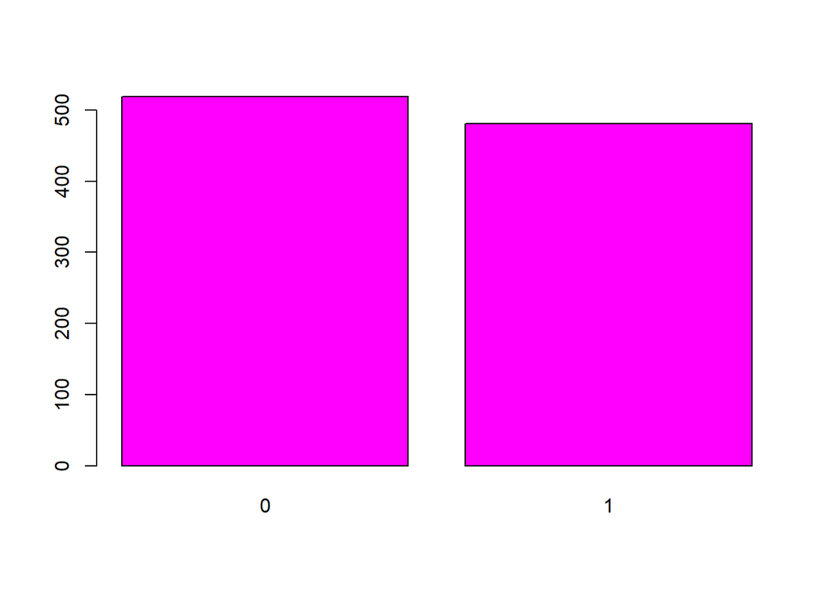

```r
Gender <- ads$Male
Gender_frequency <- table(Gender)
barplot(Gender_frequency, col="Magenta")
```

There are more females than males(0-Females, 1-Males)

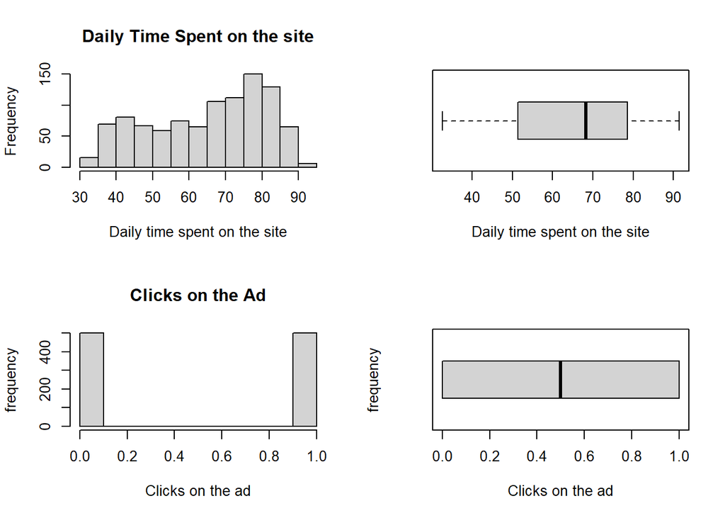

```r
Time_spent <- ads$Daily.Time.Spent.on.Site
clicks <- ads$Clicked.on.Ad
par(mfrow=c(2,2))
hist(Time_spent,xlab='Daily time spent on the site', main='Daily Time Spent on the site')
boxplot(Time_spent,xlab='Daily time spent on the site', horizontal=TRUE)
hist(clicks, xlab='Clicks on the ad', ylab='frequency', main='Clicks on the Ad')
boxplot(clicks, xlab='Clicks on the ad', ylab='frequency', horizontal=TRUE)
```

With a maximum of 90 minutes,the average time spent daily on the site is 65 minutes. As displayed in the output, the number of people who clicked on the ads is equal to those who did not click.

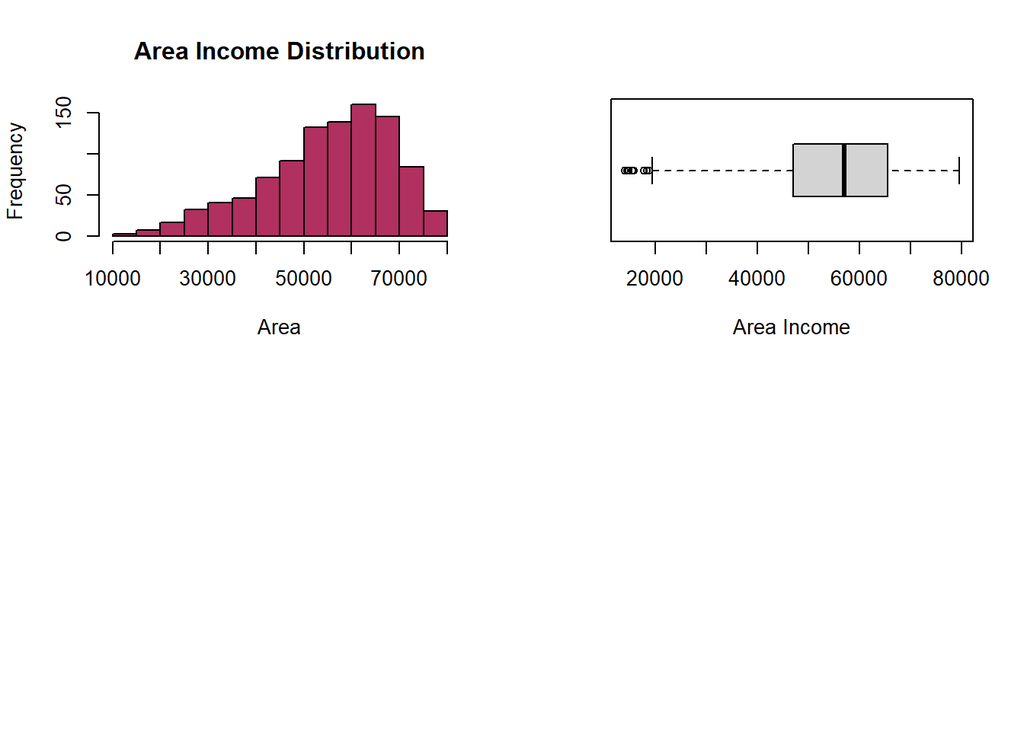

```r
#Checking distribution of Area Income
income <-ads$Area.Income
par(mfrow=c(2,2))
hist(income, main='Area Income Distribution',xlab='Area',col='Maroon')

boxplot(income,xlab = 'Area Income', horizontal=TRUE)
```

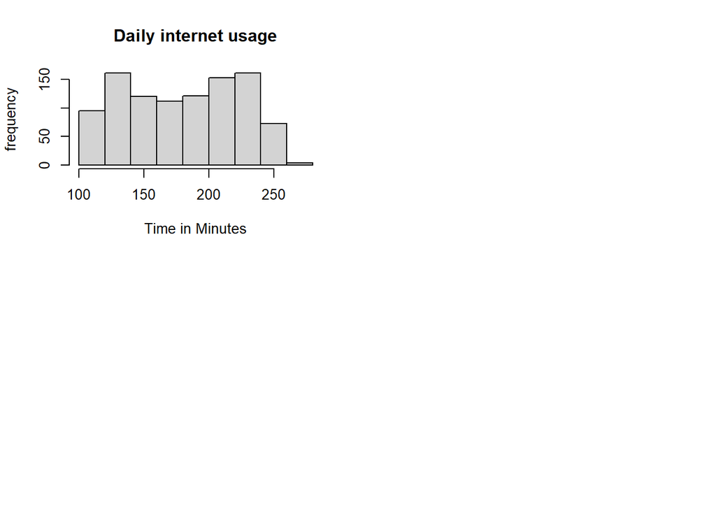

```r
Internet<- ads$Daily.Internet.Usage
par(mfrow=c(2,2))
hist(Internet, xlab = 'Time in Minutes', ylab = 'frequency',main = 'Daily internet usage')
```

The output displays that there is no skeweness in Daily Internet Usage

##Bivariate Analysis #Checking for covariance This measures how two variables defer from each other

```r
#let's first check the relationship between daily time spent on usage vs the daily internet usage
Time_spent <- ads$Daily.Time.Spent.on.Site
Internet <- ads$Daily.Internet.Usage
cov(Time_spent,Internet)
```

```
## [1] 360.9919
```

#Checking for Correlation This measures the strength of the relationship between two variables and the direction of the relationship.

```r
Time_spent <- ads$Daily.Time.Spent.on.Site
Internet <- ads$Daily.Internet.Usage
cor(Time_spent,Internet)
```

```
## [1] 0.5186585
```

The output displays that Daily time spent on site and daily internet usage are fairly correlated as they have a correlation of 0.518

#Pairplot(Histograms)

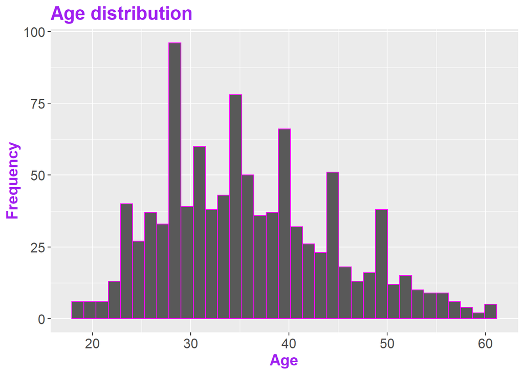

```r
library(ggplot2)
options(repr.plot.width = 13, repr.plot.height = 7)
ggplot(data = ads, aes(x = Age, fill = Clicked.on.Ad))+
 geom_histogram(bins = 35, color = 'Magenta') +
 labs(title = 'Age distribution', x = 'Age', y = 'Frequency', fill = 'Clicked on ad') +
 scale_color_brewer(palette = 'Set1') +
 theme(plot.title = element_text(size = 18, face = 'bold', color = 'purple'),
 axis.title.x = element_text(size = 15, face = 'bold', color = 'purple'),
 axis.title.y = element_text(size = 15, face = 'bold', color = 'purple'),
 axis.text.x = element_text(size = 13, angle = 0),
 axis.text.y = element_text(size = 13),
 legend.title = element_text(size = 13, color = 'purple'),
 legend.text = element_text(size = 12))
```

#Scatterplot

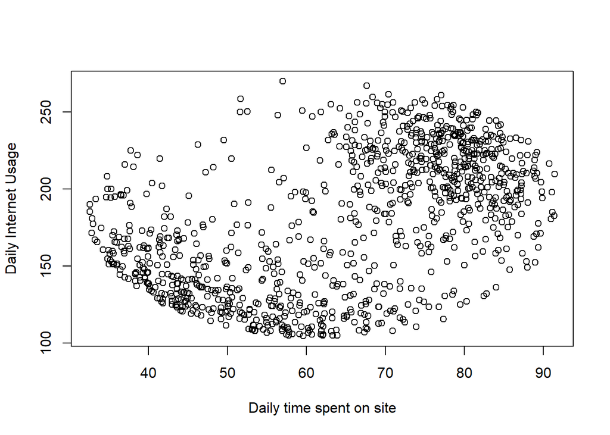

```r
Time_spent <- ads$Daily.Time.Spent.on.Site
Internet<- ads$Daily.Internet.Usage
plot(Time_spent, Internet, xlab="Daily time spent on site", ylab="Daily Internet Usage")
```

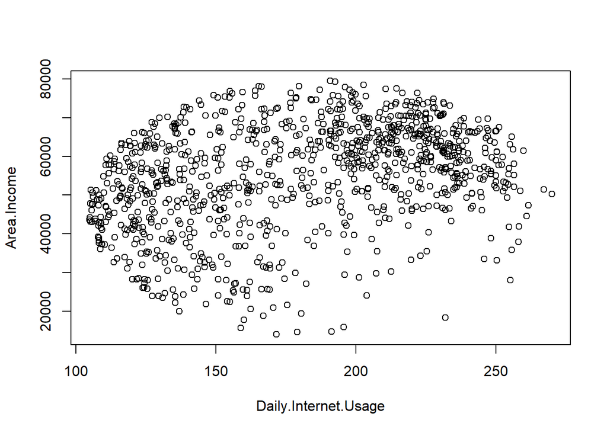

```r
plot(Area.Income ~ Daily.Internet.Usage, data = ads)
```

```r
frequency_ads = table(ads$Clicked.on.Ad)
frequency_ads
```

```
##
##   0   1
## 500 500
```

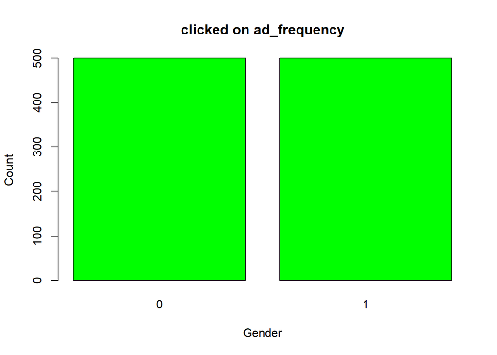

```r
# Barplot for clicked on ad variable.
#
bar_ads = barplot(frequency_ads, main = 'clicked on ad_frequency',
 xlab = 'Gender', ylab = 'Count', col = 'green')
```

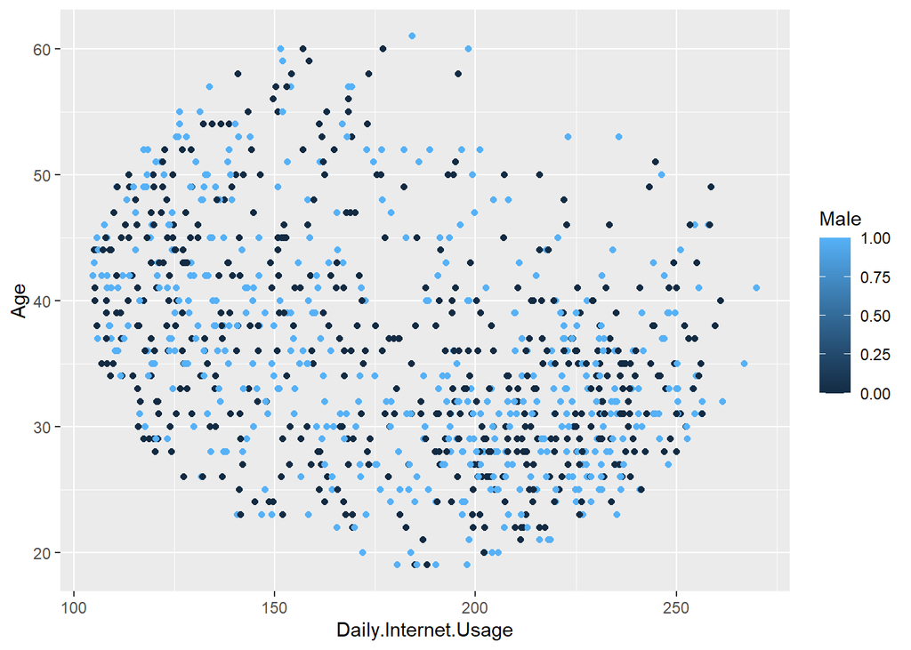

```r
ggplot(data = ads) +
 geom_point(mapping = aes(x = Daily.Internet.Usage , y= Age, fill = Male, colour = Male))
```

#Multivariate Analysis

#Using a correlation plot

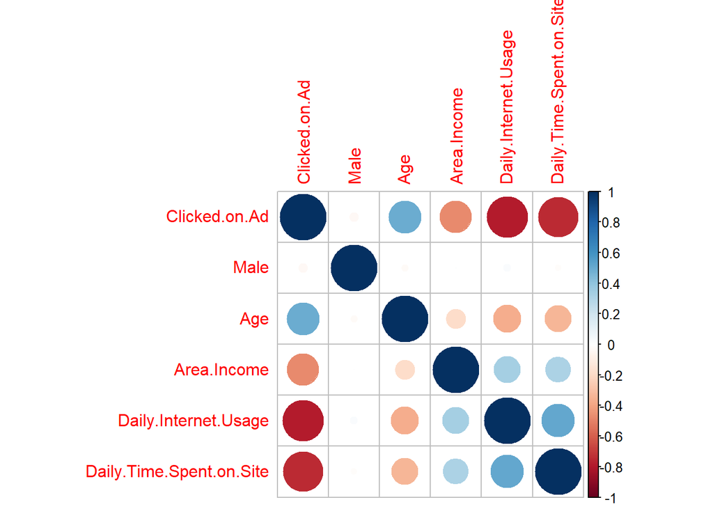

```r
sub_data <- c('Clicked.on.Ad', 'Male', 'Age', 'Area.Income',
'Daily.Internet.Usage', 'Daily.Time.Spent.on.Site')
num <- ads[,sub_data]
num_cor <- cor(num)
library(corrplot)
corrplot(num_cor)
```